# Lab1

## Exercise 4

Create a new object called under23_and_smoke that contains all observations of respondents under the age of 23 that have smoked 100 cigarettes in their lifetime. Write the command you used to create the new object as the answer to this exercise.

Answer 4.

```r
under23_and_smoke<-subset(cdc, smoke100 = 1 & age < 30)
head(under23_and_smoke)
```

```
##     genhlth exerany hlthplan smoke100 height weight wtdesire age gender
## 1      good       0        1        0     70    175      175  77      m
## 2      good       0        1        1     64    125      115  33      f
## 3      good       1        1        1     60    105      105  49      f
## 4      good       1        1        0     66    132      124  42      f
## 5 very good       0        1        0     61    150      130  55      f
## 6 very good       1        1        0     64    114      114  55      f
```

construct a box plot for a single variable

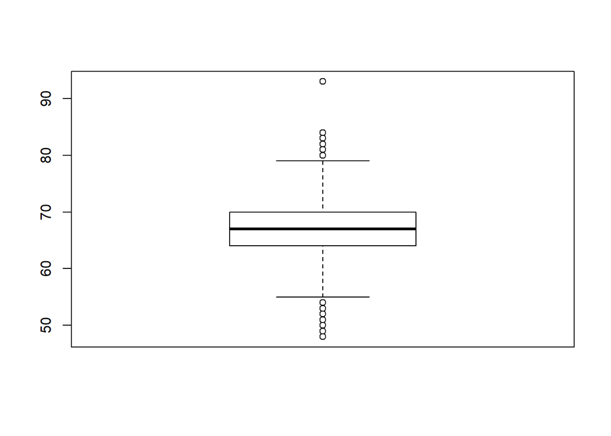

```r
boxplot(cdc$height)
```

compare the locations of the components of the box by examining the summary statistics.

```r
summary(cdc$height)
```

```
##    Min. 1st Qu.  Median    Mean 3rd Qu.    Max.
##   48.00   64.00   67.00   67.18   70.00   93.00
```

compare the heights of men and women using boxplot

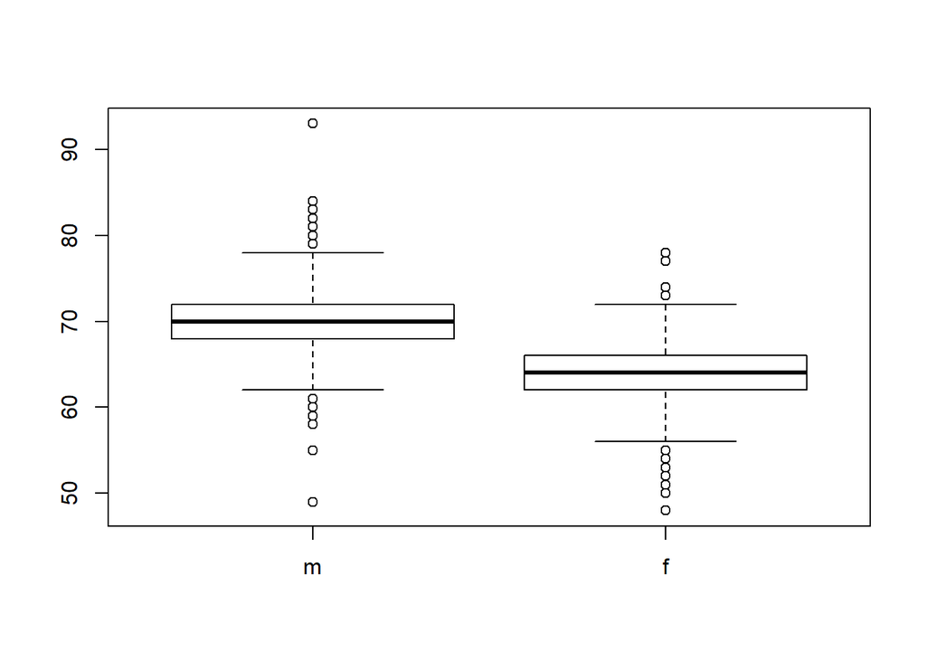

```r
boxplot(cdc$height ~ cdc$gender)
```

make a new object called bmi and then creates box plots of these values, defining groups by the variable cdc$genhlth.

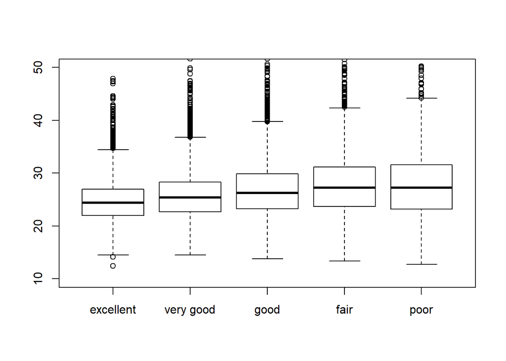

```r
bmi <- (cdc$weight / cdc$height^2) * 703
boxplot(bmi ~ cdc$genhlth,ylim=c(10,50))
```

## Exercise 5

What does this box plot show? Pick another categorical variable from the data set and see how it relates to BMI. List the variable you chose, why you might think it would have a relationship to BMI, and indicate what the figure seems to suggest.

Answer 5.

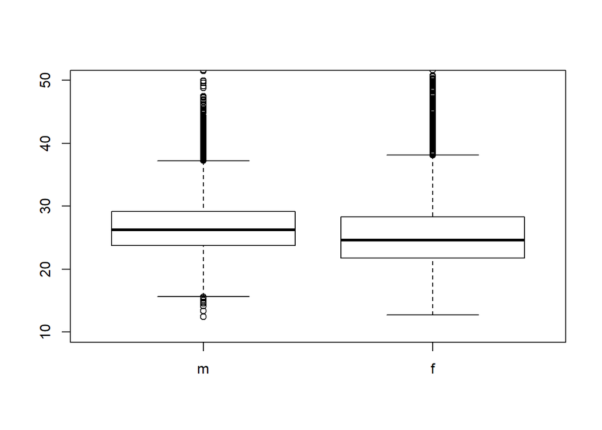

```r
## using 'gender' as a variable
bmi <- (cdc$weight / cdc$height^2) * 703
boxplot(bmi ~ cdc$gender,ylim=c(10,50))
```

## On Your Own

1. Make a scatterplot of weight versus desired weight. Describe the relationship between these two variables.

Answer 1.

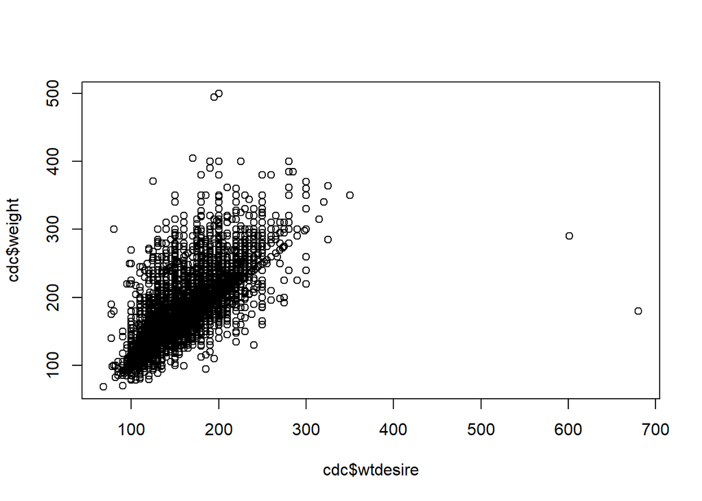

```r
plot(cdc$weight~cdc$wtdesire)
```

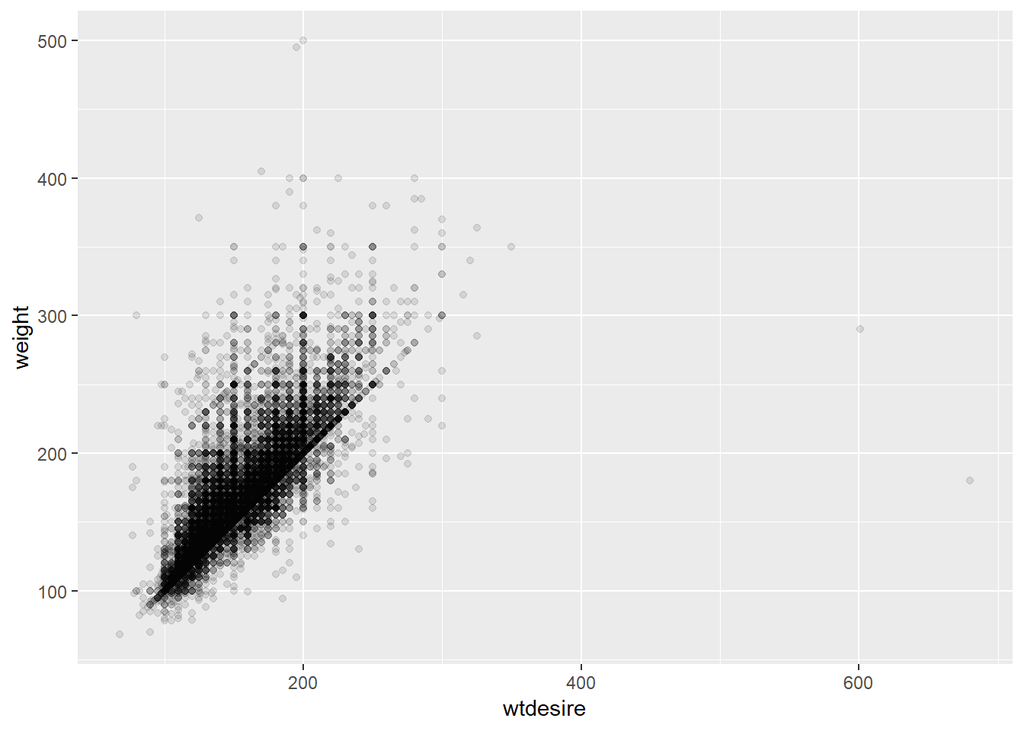

```r
library(ggplot2)
ggplot(cdc,aes(wtdesire,weight)) + geom_point(alpha=1/10)
```

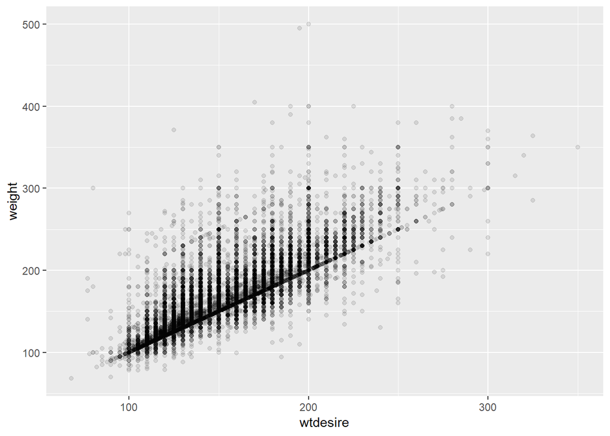

```r
ggplot(cdc[which(cdc$wtdesire < 400),],aes(wtdesire,weight)) + geom_point(alpha=1/10)
```

Current weight and desired weight factors are correlated.Seems like more number of respondants have their desired weight equal to their current weight. For some people current weight tends to be higher than their desired weight.

2.Let’s consider a new variable: the difference between desired weight (wtdesire) and current weight (weight). Create this new variable by subtracting the two columns in the data frame and assigning them to a new object called wdiff.

Answer 2.

```r
wdiff<-cdc$weight-cdc$wtdesire
head(wdiff)
```

```
## [1]  0 10  0  8 20  0
```

the data type of ‘wdiff’ is: numeric and discrete. If an observation wdiff is 0: The respondant have the same current weight and desired weight if wdiff is positive: respondants current weight > desired weight(They want to loose weight) if wdiff is negetive: respondants current weight < desired weight(They may or may not want to loose weight)

4. Describe the distribution of wdiff in terms of its center, shape, and spread, including any plots you use. What does this tell us about how people feel about their current weight?

Answer 4.

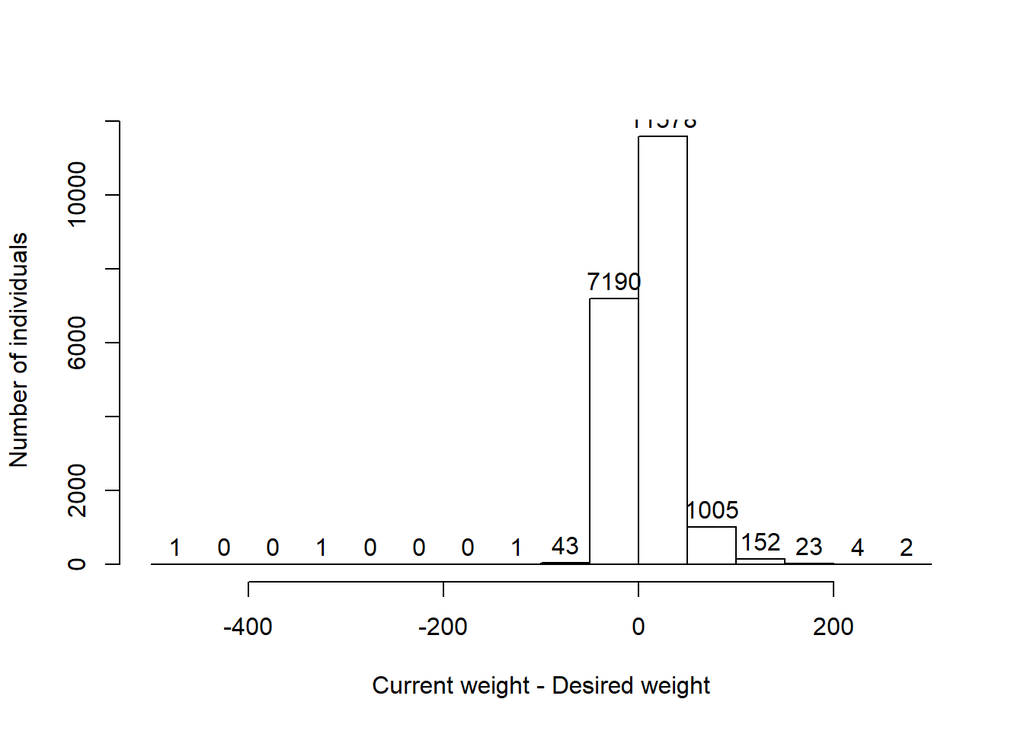

```r
hist(wdiff,xlab="Current weight - Desired weight",ylab="Number of individuals",main="",labels=TRUE)
```

```r
median(wdiff)
```

```
## [1] 10
```

By the above obervation , there are more respondants who wish to loose weight or their current weight is higher that the desired weight.

Center of the data is 10 , means half of the respondants current weight is higher than the desired weight and wish to loose 10 pounds.

5. Using numerical summaries and a side-by-side box plot, determine if men tend to view their weight differently than women.

Answer 5.

```r
##Analyzing for males
summary(cdc$weight,cdc$gender=='m')
```

```
##    Min. 1st Qu.  Median    Mean 3rd Qu.    Max.
##    68.0   140.0   165.0   169.7   190.0   500.0
```

```r
##Analyzing for females
summary(cdc$weight,cdc$gender=='f')
```

```
##    Min. 1st Qu.  Median    Mean 3rd Qu.    Max.
##    68.0   140.0   165.0   169.7   190.0   500.0
```

create a dataframe

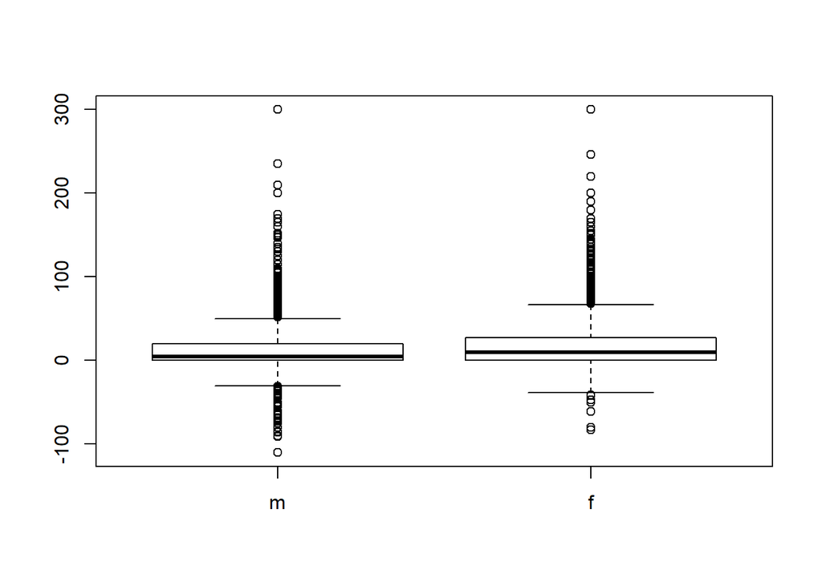

```r
weight_gender<-data.frame(wdiff = wdiff,gender = cdc$gender)

## remove the two outliers who's data points show 600+ pounds weight
weight_gender <- weight_gender[which(cdc$wtdesire < 600),]
## generate the side by side boxplot
boxplot(wdiff ~ gender,data=weight_gender)
```

6. Now it’s time to get creative. Find the mean and standard deviation of weight and determine what proportion of the weights are within one standard deviation of the mean.

Answer 6.

```r
mean(cdc$weight)
```

```
## [1] 169.683
```

```r
sd(cdc$weight)
```

```
## [1] 40.08097
```

what proportion of the weights are within one standard deviation of the mean.

```r
below_sd <- mean(cdc$weight) - sd(cdc$weight)
above_sd <- mean(cdc$weight) + sd(cdc$weight)
length(which(cdc$weight >= below_sd & cdc$weight <= above_sd))/20000
```

```
## [1] 0.7076
```